# COMPSCIX 415.2 Homework 1

Chunduri SriKeerthi Chandra

Jun 12th 2018

My Github repository for my assignments can be found at this URL: https://github.com/skcchunduri/compscix-415-2-assignments.git

```r
library(mdsr)
library(tidyverse)
data("WorldCities")
```

#### QUESTION 1: How many observations and variables are there in this data set? What are

#### some of the variable names? Type up your answer in your document using complete sentences.

WorldCities dataset captures **23018** observations made for **10** variables ( code, name, latitude, longitude, country, countryRegion, population, regionCode, region, date ). These variables capture different aspects of each city that help locate the city and know its population.

```r
WorldCities <- head(WorldCities, 200)
country_col <- WorldCities$country
```

Countries from sample dataset [ AD, AE, AF, AG, AI, AL, AM, AO, AR ]. Different regions that these countries belong to are :

#### QUESTION 2: There is a column called region in the data set. Can you extract this and show

#### only the unique values?

```r
WorldCities %>% select(region) %>% unique()
```

```
##                             region
## 1                   Europe/Andorra
## 3                       Asia/Dubai
## 15                      Asia/Kabul
## 65                 America/Antigua
## 66                America/Anguilla
## 67                   Europe/Tirane
## 87                    Asia/Yerevan
## 104                  Africa/Luanda
## 131 America/Argentina/Buenos_Aires
## 132      America/Argentina/Cordoba
## 194        America/Argentina/Salta
## 195      America/Argentina/Tucuman
## 197     America/Argentina/San_Juan
```

#### QUESTION 3: Can you extract and show the unique entries from the country column in

#### WorldCities using one line of code and two %>% operators?

A different version to select countries is:

```r
WorldCities %>% select(country) %>% unique()
```

```
##     country
## 1        AD
## 3        AE
## 15       AF
## 65       AG
## 66       AI
## 67       AL
## 87       AM
## 104      AO
## 131      AR
```

### Histogtam

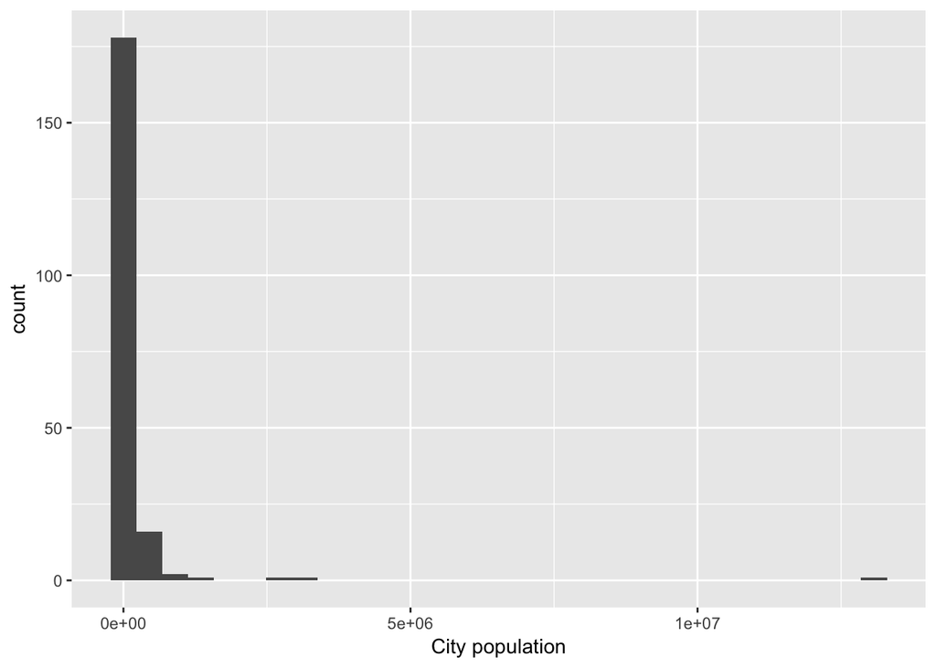

```r
WorldCities %>% ggplot(aes(x = population)) +
geom_histogram() +
xlab('City population')
```

#### QUESTION 4: Make one more histogram of the population and add a new x-label, a new ylabel,

#### a new title (use ggtitle(‘my title’)), and change the theme of the plot using theme_bw().

My Histogram using “classic dark-on-light ggplot2 theme”

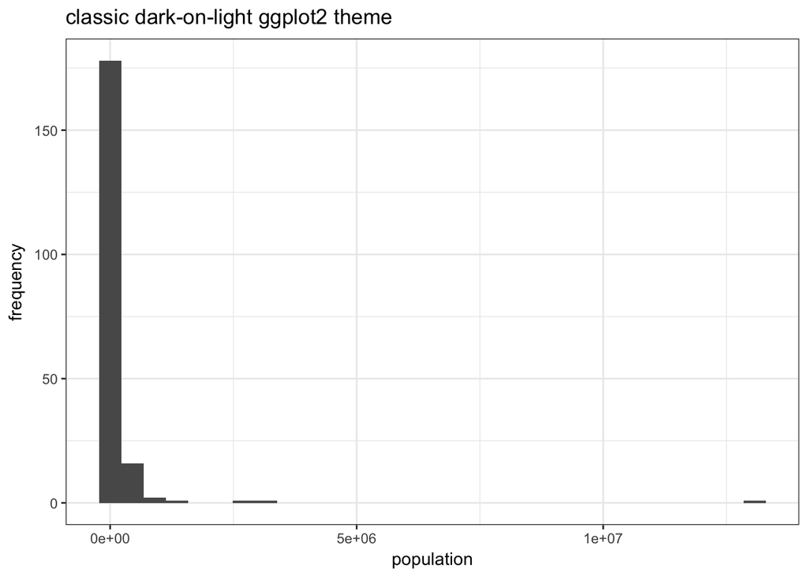

```r
WorldCities %>% ggplot(aes(x = population)) +geom_histogram() +
  theme_bw() + xlab('population') + ylab('frequency') + ggtitle('classic dark-on-light ggplot2 theme')
```